# New Zealand Warriors Merchandise

## Introduction to my data collection:

[figure not shown]

New Zealand Warriors

The primary focus of this project was to visualize certain details and statistics about the New Zealand Warriors fanbase. I built on my previous google form, this time adding another question to gather data on the age demographic of the people observed wearing the New Zealand Warriors Merchandise. The data was collected solely by myself. As mentioned in the previous project, the primary focus of the investigation was surrounding my home country, Ireland. In Ireland, it is not uncommon to witness people representing their local rugby or football teams’ jersey on a regular basis.

## Where can we find each age group of fans?

The majority of the fans were observed in stadium. The fans were spotted in larger groups than elsewhere, while other fans were spotted alone in the city. With regard to the age demographic, most fans observed were of the same age group as myself, between 18 and 25 years of age.

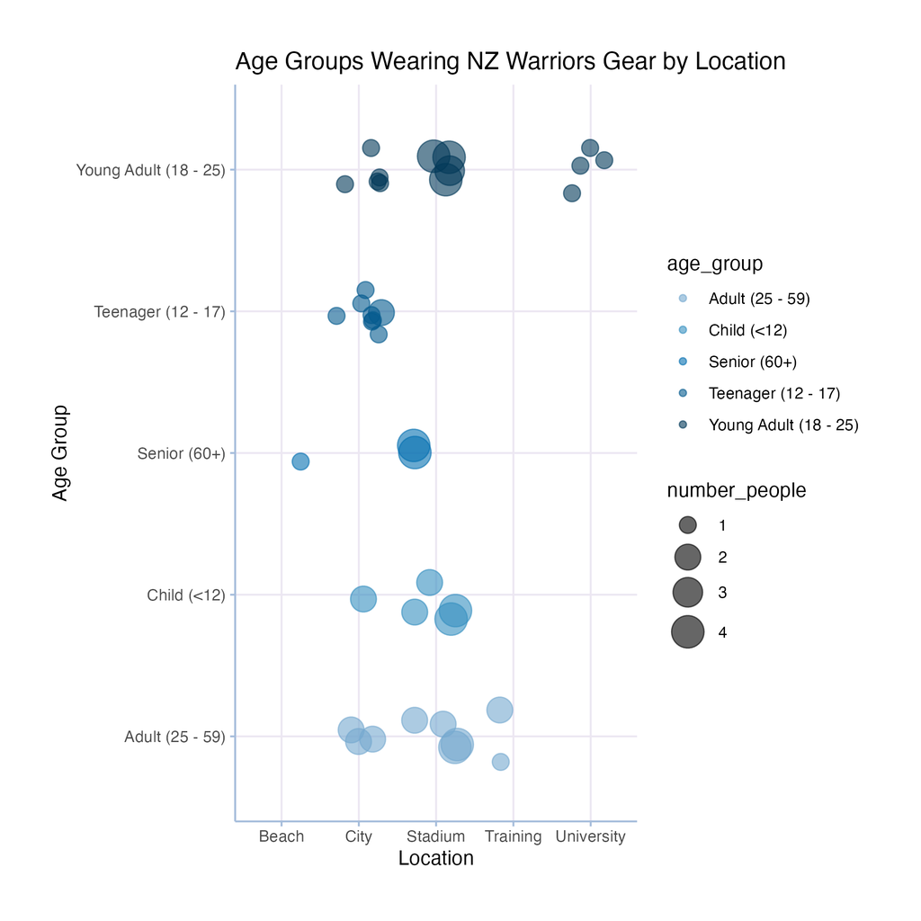

Age Groups wearing Warriors Merchandise by Location

## Where do fans meet together?

In this plot, I was interested in finding where we would find groups of supporters together, and conversely, where we would find supporters on their own. As one might expect, the majority of people observed together was at the New Zealand Warriors home stadium, whereas people were typically observed to be wearing the merchandise on their own at other locations.

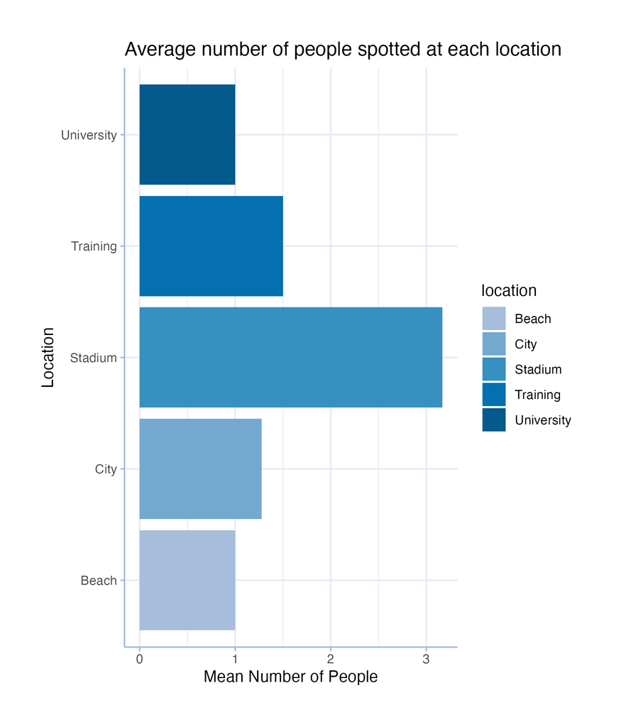

How many people are gathered together at each location

## What piece of merchandise is most common amongst fans?

Here I was simply interested in gaining an insight into the most common item of merchandise, which unsurpirisingly was the jersey, followed by the hat, then followed closely by the jacket.

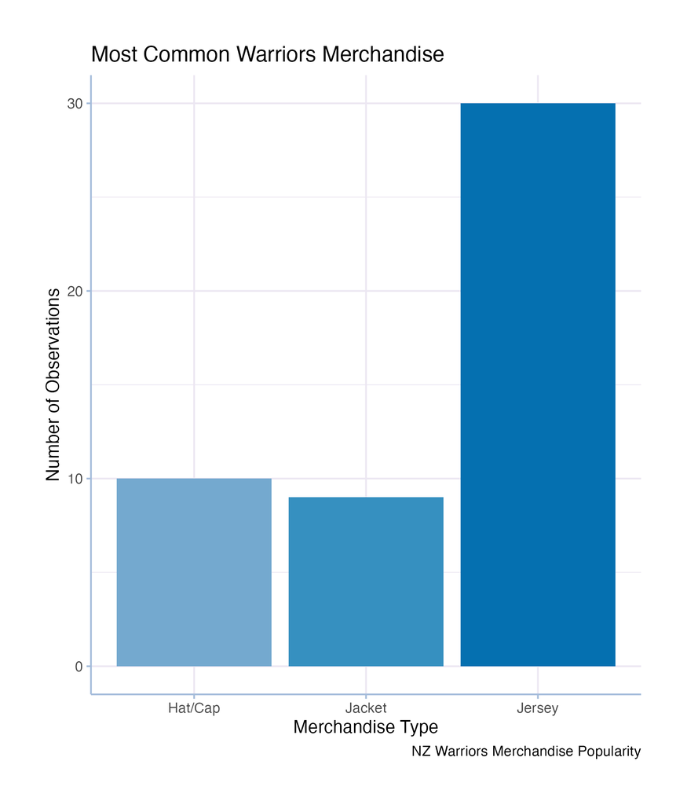

Most common merchandise

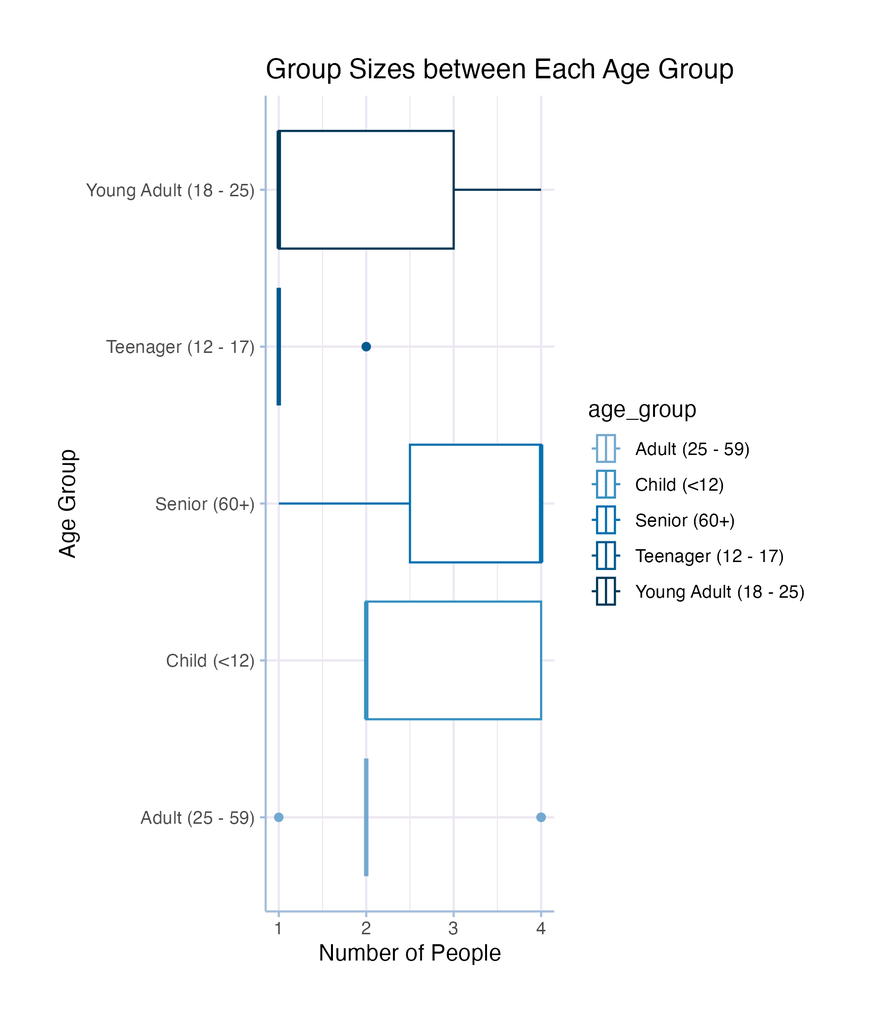

## These are the days where there were the most observations recorded

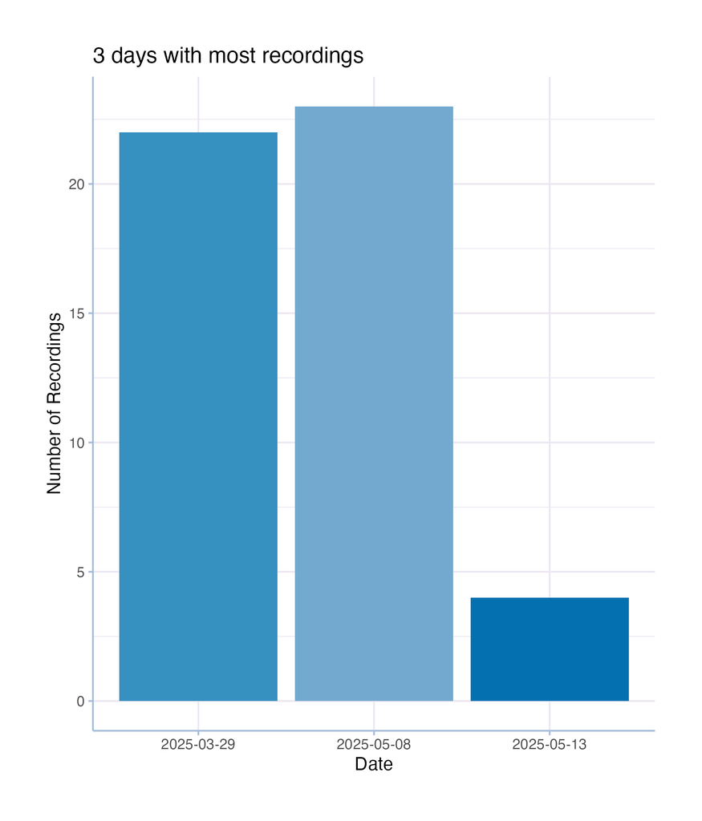

Days with the most observations

## What does this mean?

As an exchange student from Ireland, I was intrugied to learn about the difference in supporters’ clothing decisions. In Ireland, one’s local team plays an integral part in one’s clothing style, where fans almost exclusively wear their local team’s merchandise whenever that team is playing. This is is similar in Auckland, however not to the same extent. This may be due to Auckland having more rugby teams than my home city in Ireland.

[figure not shown]

Irish Rugby Supporters